# Assignment 2 Submission

Himakar Gadham, Atikant Jain

## Assignment 2 submitted by Student Name, Student ID

Himakar Gadham - 23783777, Atikant Jain - 24051868

### Statement of Contribution:

Both of us contributed equally to all the questions. We both sat together in library and worked through each question. We did it by going through labs question and answers, comparing our output with each other, clarifying doubts and clearing concepts.

## Question 1 Air Pollution and Mortality. Does pollution kill people? (30 marks)

1. (5 marks) Carry out exploratory data analysis (EDA) of this dataset, taking into account the following groups of associations with the response (see the question sheet)

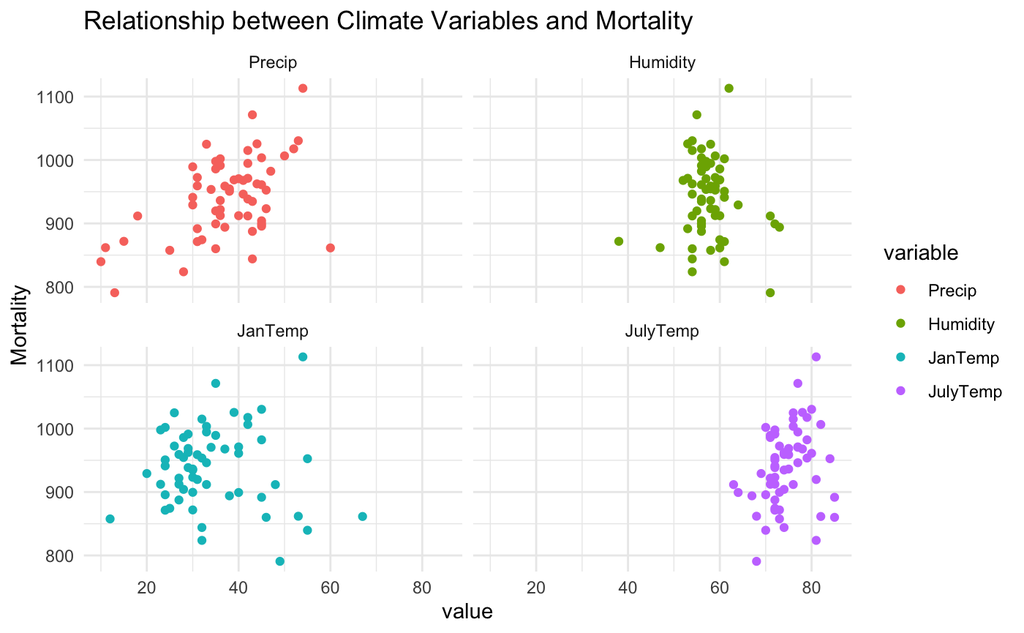

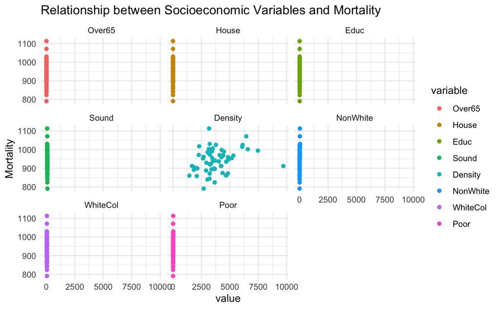

Population Density shows a moderate positive correlation with mortality. Over65, House, Educ, Sound, NonWhite, WhiteCol, and Poor do not show clear trends, suggesting weak or no correlation with mortality.

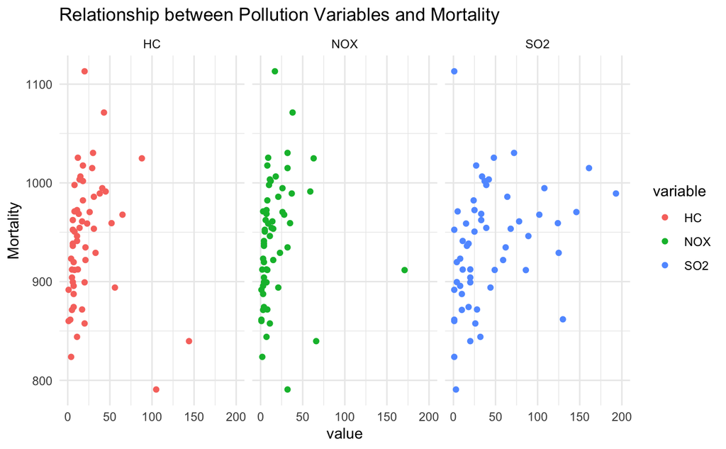

Sulfur Dioxide (SO2) shows a moderate positive correlation with mortality. Hydrocarbons (HC) and Nitrogen Oxides (NOX) do not show clear trends, suggesting weak or no correlation with mortality.

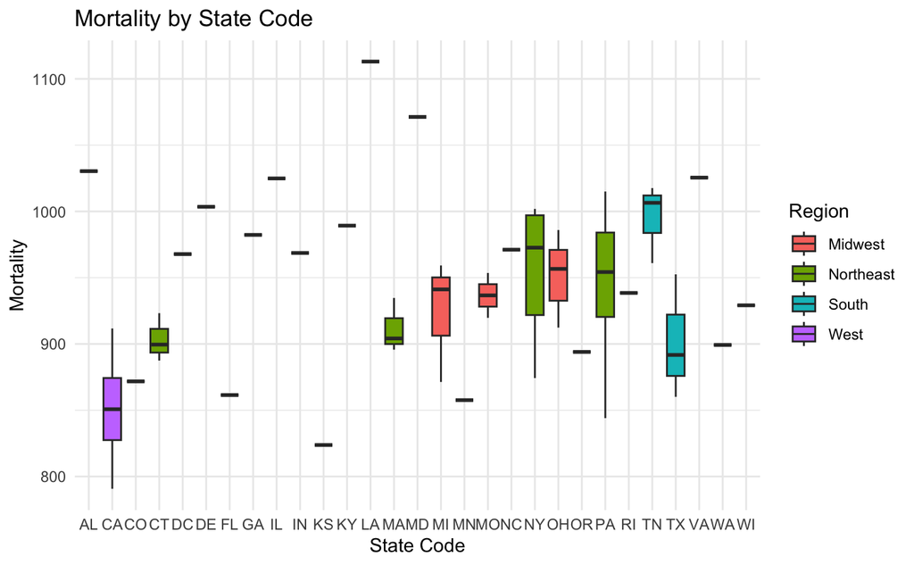

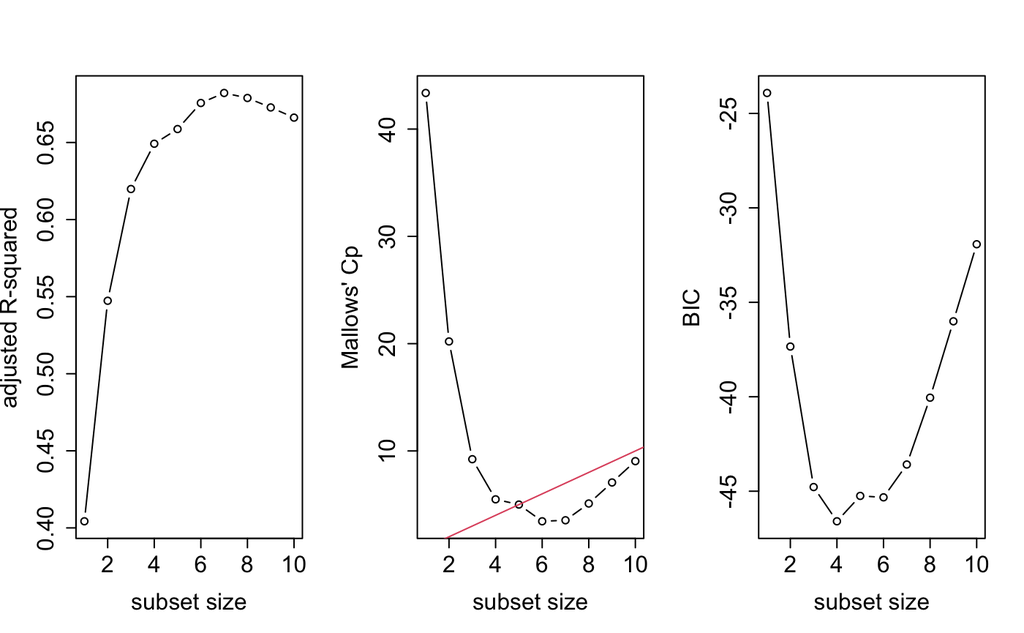

```
[1] 7
[1] 4
[1] 6
```

```
[1] "(Intercept)" "Precip"      "JanTemp"     "JulyTemp"    "House"       "Educ"        "Density"     "NonWhite"
[1] "(Intercept)" "JanTemp"     "House"       "Educ"        "NonWhite"
[1] "(Intercept)" "Precip"      "JanTemp"     "JulyTemp"    "Educ"        "Density"     "NonWhite"
```

3. (4 marks) Fit an optimal model with the lowest $C_p$ as obtained in (b). Write the equation of this fitted model. Interpret this model.

```
Call:
lm(formula = Mortality ~ Precip + JanTemp + JulyTemp + Educ +
    Density + NonWhite, data = pollution)

Residuals:
    Min      1Q  Median      3Q     Max
-80.685 -21.529   1.422  22.777  83.055

Coefficients:
              Estimate Std. Error t value Pr(>|t|)
(Intercept)  1.242e+03  1.233e+02  10.078 6.41e-14 ***
Precip       1.401e+00  6.074e-01   2.307   0.0250 *
JanTemp     -1.684e+00  5.330e-01  -3.161   0.0026 **
JulyTemp    -2.840e+00  1.289e+00  -2.203   0.0319 *
Educ        -1.616e+01  6.652e+00  -2.429   0.0186 *
Density      7.570e-03  3.316e-03   2.283   0.0265 *
NonWhite     5.275e+00  6.906e-01   7.639 4.24e-10 ***
---
Signif. codes:  0 ‘***’ 0.001 ‘**’ 0.01 ‘*’ 0.05 ‘.’ 0.1 ‘ ’ 1

Residual standard error: 35.43 on 53 degrees of freedom
Multiple R-squared:  0.7086,    Adjusted R-squared:  0.6756
F-statistic: 21.48 on 6 and 53 DF,  p-value: 1.305e-12
```

### Mortality = 1.242e+03 + 1.401e+00*Precip -1.684e+00*JanTemp -2.840e+00*JulyTemp -1.616e+01*Educ + 7.570e-03*Density + 5.275e+00*NonWhite

Overall Fit: The model explains 70.86% of the variability in mortality (R-squared = 0.7086). The model is highly significant (F-statistic = 21.48, p-value = 1.305e-12).

Precipitation: Each unit increase in precipitation is associated with a 1.401 increase in mortality (p = 0.0250). January Temperature: Each unit increase in January temperature is associated with a 1.684 decrease in mortality (p = 0.0026). July Temperature: Each unit increase in July temperature is associated with a 2.840 decrease in mortality (p = 0.0319). Education Level: Each unit increase in education level is associated with a 16.16 decrease in mortality (p = 0.0186). Population Density: Each unit increase in population density is associated with a 0.00757 increase in mortality (p = 0.0265). Percentage of Non-White Population: Each unit increase in the non-white population percentage is associated with a 5.275 increase in mortality (p < 0.001).

4. (7 marks) Perform diagnostics checking on the model in (c). Do you think there are influential points in the data? Identify the cities which are influential points using leverage and Cook’s distance respectively.

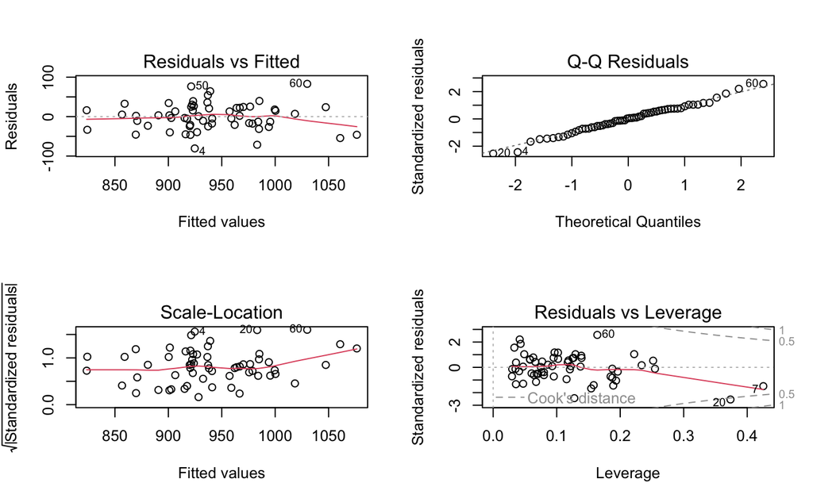

```r
par(mfrow=c(2,2))
plot(model)
```

Residuals vs Fitted (top-left) shows a smoothing curve with no pattern Scale-Location (bottom-left) shows a slight increasing trend Normal Q-Q (top-right) shows most observations lie around the straight line Residuals vs Leverage (bottom-right) shows leverage points and potential outliers

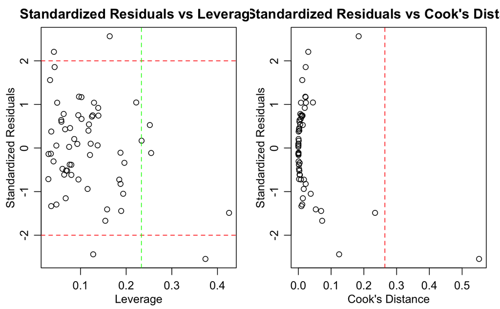

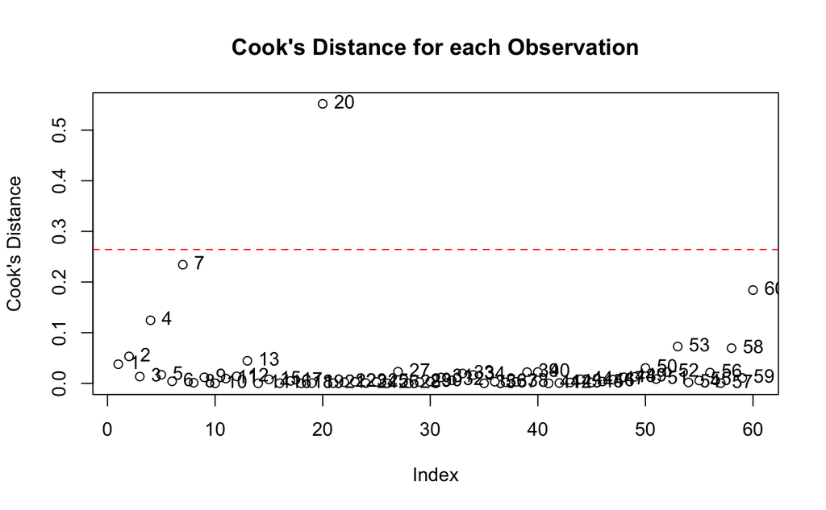

```
High leverage points: 3 7 8 13 19 20
Outliers: 4 20 50 60
```

5. (5 marks) Using the model obtained in (c), add the three pollution variables (transformed to their natural logarithm) and obtain the p-value from the extra-sum-of-squares F-test due to their addition. Summarise your findings in a few concise sentences.

```r
model2 <- lm(Mortality ~ Precip + JanTemp + JulyTemp + Educ + Density + NonWhite+ log(HC) + log(NOX) + log(SO2), data = pollution)
summary(model2)
```

```
Call:
lm(formula = Mortality ~ Precip + JanTemp + JulyTemp + Educ +
    Density + NonWhite + log(HC) + log(NOX) + log(SO2), data = pollution)

Residuals:
   Min     1Q Median     3Q    Max
-78.49 -18.65   4.88  19.27  61.66

Coefficients:
              Estimate Std. Error t value Pr(>|t|)
(Intercept)  1.143e+03  1.534e+02   7.448 1.20e-09 ***
Precip       2.036e+00  6.534e-01   3.117  0.00303 **
JanTemp     -1.976e+00  6.559e-01  -3.013  0.00405 **
JulyTemp    -2.204e+00  1.646e+00  -1.339  0.18673
Educ        -1.160e+01  6.447e+00  -1.800  0.07789 .
Density      5.178e-03  3.482e-03   1.487  0.14329
NonWhite     4.505e+00  8.138e-01   5.536 1.14e-06 ***
log(HC)     -2.820e+01  1.475e+01  -1.912  0.06158 .
log(NOX)     4.343e+01  1.431e+01   3.034  0.00382 **
log(SO2)    -5.149e+00  6.431e+00  -0.801  0.42709
---
Signif. codes:  0 ‘***’ 0.001 ‘**’ 0.01 ‘*’ 0.05 ‘.’ 0.1 ‘ ’ 1

Residual standard error: 32.47 on 50 degrees of freedom
Multiple R-squared:  0.7691,    Adjusted R-squared:  0.7275
F-statistic:  18.5 on 9 and 50 DF,  p-value: 4.593e-13
```

```r
model_comparision <- anova(model, model2)
model_comparision
```

```
Analysis of Variance Table

Model 1: Mortality ~ Precip + JanTemp + JulyTemp + Educ + Density + NonWhite
Model 2: Mortality ~ Precip + JanTemp + JulyTemp + Educ + Density + NonWhite +
    log(HC) + log(NOX) + log(SO2)
  Res.Df   RSS Df Sum of Sq     F   Pr(>F)
1     53 66518
2     50 52712  3     13806 4.365 0.008313 **
---
Signif. codes:  0 ‘***’ 0.001 ‘**’ 0.01 ‘*’ 0.05 ‘.’ 0.1 ‘ ’ 1
```

We got the p value from the extra-sum-of-squares F-Test as 0.008313. Significance of Additional Predictors: The additional predictors log(HC) + log(NOX) + log(SO2) significantly improve the model fit, as indicated by the significant p-value (0.008313). This suggests that including these pollution variables in the model provides a better explanation of the variability in mortality. And we reject the Null Hypothesis. Model Comparison: Model 2, which includes the additional pollution variables, is statistically significantly better than Model 1, which only includes the climate and socioeconomic variables. Model 1 has an RSS of 66518 and Model 2 has an RSS of 52712. The decrease in RSS indicates that Model 2 explains more variability in the data than Model 1.

## Question 2 Body Measurements (25 marks)

1. (4 marks) Carry out exploratory data analysis (EDA) of this dataset before you do any modelling.

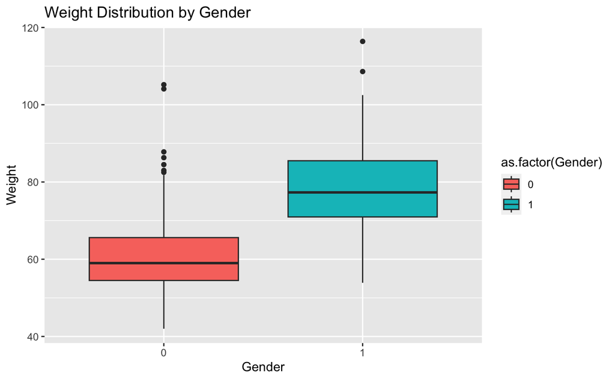

**Interpretation**: - **Boxplot of Weight by Gender**: Males tend to have higher weights compared to females. This suggests a potential relationship between gender and weight.

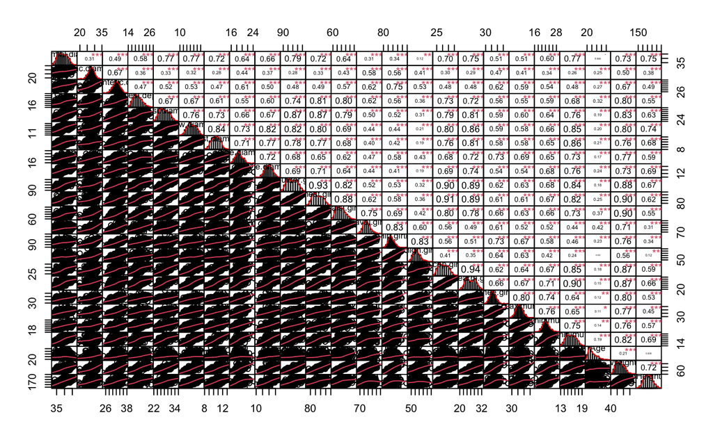

- **Correlation Matrix**: Strong correlations exist among many girth measurements and between height and weight, indicating potential multicollinearity issues in the model.
2. (10 marks) After the exploratory analysis has been carried out, split the dataset into a training set and a testing set so that the training set contains 80% of the data and the testing set contains 20%. Construct a multiple linear regression model for this dataset using the training set to create 2 final fitted models at a significance level of 10%, based on the following variable selection methods :

   ```
      - (Model 1) The Forward selection;
      - (Model 2) The Backward selection.
   ```

Write the two fitted model equations and compare them in a few concise sentences.

```r
# Set a random seed for reproducibility
set.seed(2401)
TestIndex <- sample(nrow(body_data), floor(0.2 * nrow(body_data)))
Test.body_data <- body_data[TestIndex, ]
Train.body_data <- body_data[-TestIndex, ]
```

```r
lm.all <- lm(Weight ~ ., data = Train.body_data)
summary(lm.all)
```

```
Call:
lm(formula = Weight ~ ., data = Train.body_data)

Residuals:
    Min      1Q  Median      3Q     Max
-7.3377 -1.2952 -0.0582  1.2598  9.0126

Coefficients:
                          Estimate Std. Error t value Pr(>|t|)
(Intercept)             -118.73262    3.07968 -38.554  < 2e-16 ***
Biacromial.diameter       -0.05031    0.07659  -0.657 0.511610
Biiliac.diameter           0.07509    0.07654   0.981 0.327190
Bitrochanteric.diameter   -0.07215    0.10346  -0.697 0.485998
Chest.depth                0.31033    0.07710   4.025 6.87e-05 ***
Chest.diameter             0.16640    0.09209   1.807 0.071554 .
Elbow.diameter             0.21094    0.20682   1.020 0.308408
Wrist.diameter             0.34573    0.25829   1.339 0.181512
Knee.diameter              0.41808    0.16438   2.543 0.011373 *
Ankle.diameter             0.13886    0.18102   0.767 0.443499
Shoulder.girth             0.08079    0.03533   2.287 0.022762 *
Chest.girth                0.12684    0.04274   2.967 0.003192 **
Waist.girth                0.36034    0.03153  11.428  < 2e-16 ***
Navel.girth               -0.01943    0.02840  -0.684 0.494269
Hip.girth                  0.24877    0.05462   4.555 7.07e-06 ***
Thigh.girth                0.22579    0.06292   3.588 0.000376 ***
Bicep.girth                0.16775    0.09808   1.710 0.088009 .
Forearm.girth              0.46957    0.15620   3.006 0.002820 **
Knee.girth                 0.18883    0.08847   2.134 0.033444 *
Calf.maximum.girth         0.34377    0.07660   4.488 9.53e-06 ***
Ankle.minimum.girth        0.02250    0.11475   0.196 0.844631
Wrist.minimum.girth       -0.39786    0.23130  -1.720 0.086221 .
Age                       -0.06126    0.01472  -4.161 3.92e-05 ***
Height                     0.30064    0.02075  14.485  < 2e-16 ***
Gender                    -1.47242    0.61374  -2.399 0.016915 *
---
Signif. codes:  0 ‘***’ 0.001 ‘**’ 0.01 ‘*’ 0.05 ‘.’ 0.1 ‘ ’ 1

Residual standard error: 2.146 on 381 degrees of freedom
Multiple R-squared:  0.9762,    Adjusted R-squared:  0.9747
F-statistic: 650.3 on 24 and 381 DF,  p-value: < 2.2e-16
```

```r
# Forward selection
lm.0 <- lm(Weight ~ 1, data = Train.body_data) # Set up simplest model to start with
summary(lm.0)
```

```
Call:
lm(formula = Weight ~ 1, data = Train.body_data)

Residuals:
    Min      1Q  Median      3Q     Max
-25.395 -10.795  -1.295  10.205  47.805

Coefficients:
            Estimate Std. Error t value Pr(>|t|)
(Intercept)  68.5946     0.6693   102.5   <2e-16 ***
---
Signif. codes:  0 ‘***’ 0.001 ‘**’ 0.01 ‘*’ 0.05 ‘.’ 0.1 ‘ ’ 1

Residual standard error: 13.49 on 405 degrees of freedom
```

```r
lm.forward_model1 <- step(lm.0, scope = formula(lm.all), direction = "forward", trace = 0)
summary(lm.forward_model1)
```

```
Call:
lm(formula = Weight ~ Waist.girth + Height + Thigh.girth + Forearm.girth +
    Shoulder.girth + Calf.maximum.girth + Hip.girth + Chest.girth +
    Knee.diameter + Age + Chest.depth + Gender + Knee.girth +
    Chest.diameter + Bicep.girth + Elbow.diameter + Wrist.minimum.girth +
    Wrist.diameter, data = Train.body_data)

Residuals:
    Min      1Q  Median      3Q     Max
-7.3979 -1.2832 -0.0807  1.2514  9.0969

Coefficients:
                      Estimate Std. Error t value Pr(>|t|)
(Intercept)         -118.94354    3.00524 -39.579  < 2e-16 ***
Waist.girth            0.35664    0.02917  12.228  < 2e-16 ***
Height                 0.30191    0.01889  15.986  < 2e-16 ***
Thigh.girth            0.23965    0.06154   3.894 0.000116 ***
Forearm.girth          0.48622    0.15402   3.157 0.001720 **
Shoulder.girth         0.07093    0.03335   2.127 0.034038 *
Calf.maximum.girth     0.34923    0.07048   4.955 1.08e-06 ***
Hip.girth              0.22429    0.04525   4.957 1.07e-06 ***
Chest.girth            0.13685    0.04120   3.321 0.000981 ***
Knee.diameter          0.46740    0.14904   3.136 0.001843 **
Age                   -0.06130    0.01386  -4.423 1.27e-05 ***
Chest.depth            0.30357    0.07640   3.974 8.45e-05 ***
Gender                -1.43739    0.57360  -2.506 0.012623 *
Knee.girth             0.18447    0.08431   2.188 0.029273 *
Chest.diameter         0.14876    0.08756   1.699 0.090117 .
Bicep.girth            0.15346    0.09535   1.609 0.108331
Elbow.diameter         0.22482    0.19554   1.150 0.250959
Wrist.minimum.girth   -0.42530    0.21911  -1.941 0.052983 .
Wrist.diameter         0.39274    0.25308   1.552 0.121510
---
Signif. codes:  0 ‘***’ 0.001 ‘**’ 0.01 ‘*’ 0.05 ‘.’ 0.1 ‘ ’ 1

Residual standard error: 2.137 on 387 degrees of freedom
Multiple R-squared:  0.976, Adjusted R-squared:  0.9749
F-statistic: 874.8 on 18 and 387 DF,  p-value: < 2.2e-16
```

```r
#Backward selection
lm.backward_model2 <- step(lm.all,  direction = "backward", trace = 0)
summary(lm.backward_model2)
```

```
Call:
lm(formula = Weight ~ Chest.depth + Chest.diameter + Wrist.diameter +
    Knee.diameter + Shoulder.girth + Chest.girth + Waist.girth +
    Hip.girth + Thigh.girth + Bicep.girth + Forearm.girth + Knee.girth +
    Calf.maximum.girth + Wrist.minimum.girth + Age + Height +
    Gender, data = Train.body_data)

Residuals:
    Min      1Q  Median      3Q     Max
-7.3908 -1.3082 -0.1104  1.2070  9.1297

Coefficients:
                      Estimate Std. Error t value Pr(>|t|)
(Intercept)         -119.42408    2.97727 -40.112  < 2e-16 ***
Chest.depth            0.30916    0.07627   4.053 6.11e-05 ***
Chest.diameter         0.14989    0.08759   1.711 0.087823 .
Wrist.diameter         0.47684    0.24238   1.967 0.049855 *
Knee.diameter          0.49901    0.14654   3.405 0.000730 ***
Shoulder.girth         0.07223    0.03334   2.167 0.030874 *
Chest.girth            0.14158    0.04101   3.452 0.000618 ***
Waist.girth            0.35145    0.02883  12.192  < 2e-16 ***
Hip.girth              0.22937    0.04505   5.091 5.56e-07 ***
Thigh.girth            0.23220    0.06123   3.792 0.000173 ***
Bicep.girth            0.15422    0.09538   1.617 0.106735
Forearm.girth          0.51681    0.15177   3.405 0.000730 ***
Knee.girth             0.18553    0.08434   2.200 0.028412 *
Calf.maximum.girth     0.34924    0.07051   4.953 1.09e-06 ***
Wrist.minimum.girth   -0.43639    0.21899  -1.993 0.046993 *
Age                   -0.05981    0.01380  -4.333 1.88e-05 ***
Height                 0.30696    0.01837  16.705  < 2e-16 ***
Gender                -1.36753    0.57061  -2.397 0.017020 *
---
Signif. codes:  0 ‘***’ 0.001 ‘**’ 0.01 ‘*’ 0.05 ‘.’ 0.1 ‘ ’ 1

Residual standard error: 2.138 on 388 degrees of freedom
Multiple R-squared:  0.9759,    Adjusted R-squared:  0.9749
F-statistic: 925.5 on 17 and 388 DF,  p-value: < 2.2e-16
```

### Fitted Model Equations

**Model 1: Forward Selection**

Variables with a p-value greater than 0.10 (Elbow.diameter, Bicep.girth, and Wrist.diameter) will be excluded from the final model.

$$\text{Weight} = -118.94354 + 0.35664
\times \text{Waist.girth} + 0.30191 \times \text{Height} + 0.23965
\times \text{Thigh.girth} + 0.48622 \times \text{Forearm.girth} +
0.07093 \times \text{Shoulder.girth} + 0.34923 \times
\text{Calf.maximum.girth} + 0.22429 \times \text{Hip.girth} + 0.13685
\times \text{Chest.girth} + 0.46740 \times \text{Knee.diameter} -
0.06130 \times \text{Age} + 0.30357 \times \text{Chest.depth} - 1.43739
\times \text{Gender} + 0.18447 \times \text{Knee.girth} + 0.14876 \times
\text{Chest.diameter} - 0.42530 \times \text{Wrist.minimum.girth}$$

**Model 2: Backward Selection**

Variables with a p-value greater than 0.10 (Bicep.girth) will be excluded from the final model.

$$\text{Weight} = -119.42408 + 0.30916
\times \text{Chest.depth} + 0.14989 \times \text{Chest.diameter} +
0.47684 \times \text{Wrist.diameter} + 0.49901 \times
\text{Knee.diameter} + 0.07223 \times \text{Shoulder.girth} + 0.14158
\times \text{Chest.girth} + 0.35145 \times \text{Waist.girth} + 0.22937
\times \text{Hip.girth} + 0.23220 \times \text{Thigh.girth} + 0.51681
\times \text{Forearm.girth} + 0.18553 \times \text{Knee.girth} + 0.34924
\times \text{Calf.maximum.girth} - 0.43639 \times
\text{Wrist.minimum.girth} - 0.05981 \times \text{Age} + 0.30696 \times
\text{Height} - 1.36753 \times \text{Gender}$$

3. (5 marks) Perform diagnostics checking for each of the fitted models, Model 1 and Model 2 respectively.

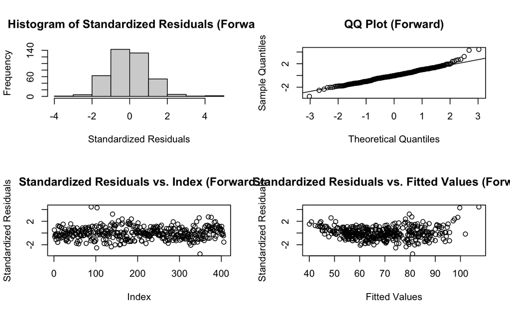

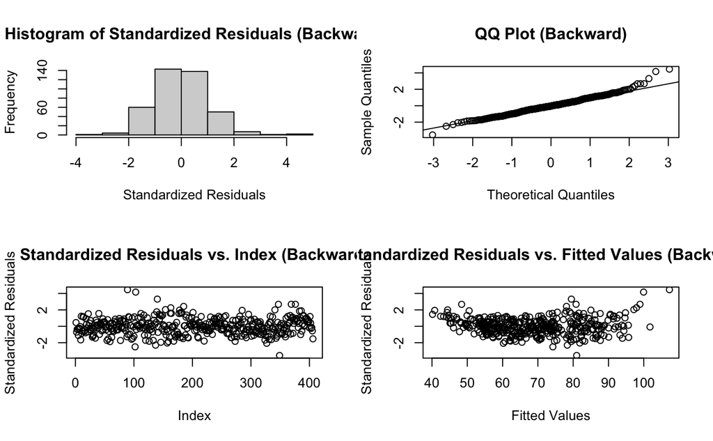

4. (6 marks). Despite any inadequacies that you may or may not have identified above, you use the two models obtained in (b) to make predictions of *Weight* in the test set.

   ```
      -  (i)  Produce a correctly drawn and labelled plot of predicted values against the actual values in the test set, and obtain the root mean squared error of prediction (RMSEP) based on each fitted model.
      -  (ii)  Using the RMSEPs and the plots you produced, comment on how well the models performed.
   ```

### Step 1: Making Predictions

Use the models from forward and backward selection methods to predict the weight in the test set.

```r
# Predicting weight using the backward selection model
predictions_backward <- predict(lm.backward_model2, newdata = Test.body_data)

# Predicting weight using the forward selection model
predictions_forward <- predict(lm.forward_model1, newdata = Test.body_data)

Actual <- Test.body_data$Weight
```

### Step 2: Calculate RMSEP

Root Mean Squared Error of Prediction (RMSEP) is a standard way to measure the error of a model in predicting quantitative data. Lower values of RMSEP indicate better fit.

```r
M <- length(Actual)

# Calculate RMSEP for the backward selection model
rmsep_backward <- sqrt(sum((Actual - predictions_backward)^2)/M)

# Calculate RMSEP for the forward selection model
rmsep_forward <- sqrt(sum((Actual - predictions_forward)^2)/M)

# Print RMSEP values
cat("RMSEP for the backward selection model:", rmsep_backward, "\n")
```

```
RMSEP for the backward selection model: 1.969358
```

```r
cat("RMSEP for the forward selection model:", rmsep_forward, "\n")
```

```
RMSEP for the forward selection model: 1.963649
```

### Step 3: Plotting Predicted vs. Actual Values

Plotting actual vs. predicted values gives a visual representation of how well the models predict new data.

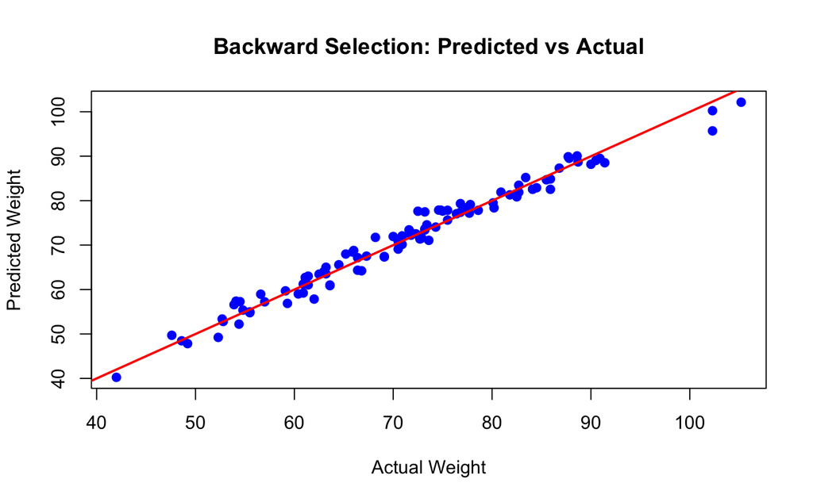

```r
# Plot for the backward selection model
plot(Actual, predictions_backward, main = "Backward Selection: Predicted vs Actual",
     xlab = "Actual Weight", ylab = "Predicted Weight", pch = 19, col = 'blue')
abline(0, 1, col = "red", lwd = 2)  # Adds a 45-degree line
```

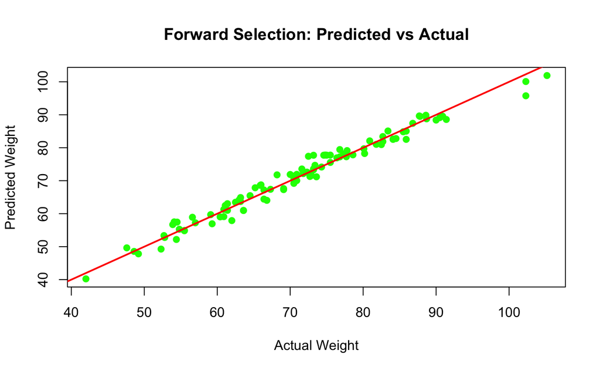

```r
# Plot for the forward selection model
plot(Actual, predictions_forward, main = "Forward Selection: Predicted vs Actual",
     xlab = "Actual Weight", ylab = "Predicted Weight", pch = 19, col = 'green')
abline(0, 1, col = "red", lwd = 2)  # Adds a 45-degree line
```

### Step 4: Comment on Model Performance

#### Analysis of RMSEP

- Both models have very similar RMSEP values, indicating that they have comparable predictive performance.
- RMSEP values are relatively low, suggesting that both models have good accuracy in predicting the weight on the test data.

#### Analysis of Predicted vs Actual Plots

- **Backward Selection Model**:
  - The plot shows that the predicted weights are closely aligned with the actual weights.
  - The points are scattered around the 45-degree line, indicating good model accuracy.
  - There are few outliers, suggesting that most predictions are accurate.
- **Forward Selection Model**:
  - Similar to the backward selection model, the predicted weights are closely aligned with the actual weights.
  - The points are also scattered around the 45-degree line, indicating good model accuracy.
  - There are few outliers, suggesting that most predictions are accurate.